# NYPD Shooting Incident Data

Lin Myat Ko

2023-09-06

# NYPD Shooting Incident Data

```r
library(tidyverse)
```

## Data Loading

The data that we are using today is from NYPD data from the following data source.

https://catalog.data.gov/dataset/nypd-shooting-incident-data-historic

```r
df <- read_csv("./NYPD/NYPD_Shooting_Incident_Data__Historic_.csv")
```

## Summary Statistics

```r
summary(df)
```

```
##   INCIDENT_KEY        OCCUR_DATE         OCCUR_TIME           BORO
##  Min.   :  9953245   Length:27312       Length:27312      Length:27312
##  1st Qu.: 63860880   Class :character   Class1:hms        Class :character
##  Median : 90372218   Mode  :character   Class2:difftime   Mode  :character
##  Mean   :120860536                      Mode  :numeric
##  3rd Qu.:188810230
##  Max.   :261190187
##
##  LOC_OF_OCCUR_DESC     PRECINCT      JURISDICTION_CODE LOC_CLASSFCTN_DESC
##  Length:27312       Min.   :  1.00   Min.   :0.0000    Length:27312
##  Class :character   1st Qu.: 44.00   1st Qu.:0.0000    Class :character
##  Mode  :character   Median : 68.00   Median :0.0000    Mode  :character
##                     Mean   : 65.64   Mean   :0.3269
##                     3rd Qu.: 81.00   3rd Qu.:0.0000
##                     Max.   :123.00   Max.   :2.0000
##                                      NA's   :2
##  LOCATION_DESC      STATISTICAL_MURDER_FLAG PERP_AGE_GROUP
##  Length:27312       Mode :logical           Length:27312
##  Class :character   FALSE:22046             Class :character
##  Mode  :character   TRUE :5266              Mode  :character
##
##
##
##
##    PERP_SEX          PERP_RACE         VIC_AGE_GROUP        VIC_SEX
##  Length:27312       Length:27312       Length:27312       Length:27312
##  Class :character   Class :character   Class :character   Class :character
##  Mode  :character   Mode  :character   Mode  :character   Mode  :character
##
##
##
##
##    VIC_RACE           X_COORD_CD        Y_COORD_CD        Latitude
##  Length:27312       Min.   : 914928   Min.   :125757   Min.   :40.51
##  Class :character   1st Qu.:1000028   1st Qu.:182834   1st Qu.:40.67
##  Mode  :character   Median :1007731   Median :194487   Median :40.70
##                     Mean   :1009449   Mean   :208127   Mean   :40.74
##                     3rd Qu.:1016838   3rd Qu.:239518   3rd Qu.:40.82
##                     Max.   :1066815   Max.   :271128   Max.   :40.91
##                                                        NA's   :10
##    Longitude        Lon_Lat
##  Min.   :-74.25   Length:27312
##  1st Qu.:-73.94   Class :character
##  Median :-73.92   Mode  :character
##  Mean   :-73.91
##  3rd Qu.:-73.88
##  Max.   :-73.70
##  NA's   :10
```

## Data Visualization

### 1. Most Risky Hour of the Day

Analyzing the variable “OCCUR TIME” could provide valuable insights into the temporal patterns of risk, particularly in differentiating the levels of safety between daytime and nighttime hours. In common sense, daytime should be safer than nighttime.

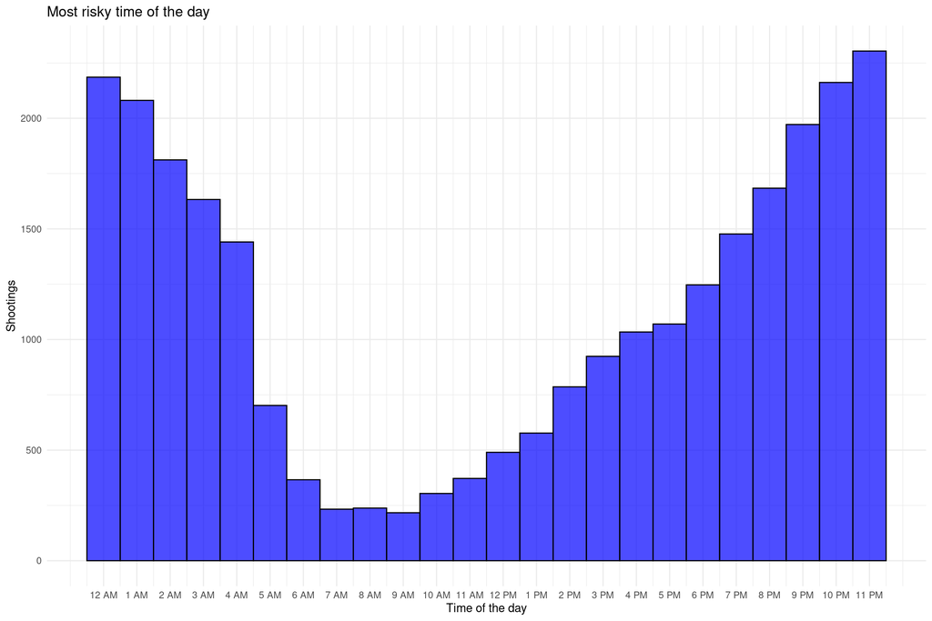

```r
breaks_hours <- seq(0, 23, 1)
labels_hours <- c("12 AM", paste0(seq(1, 11, 1), " AM"), "12 PM", paste0(seq(1, 11, 1), " PM"))


df$hour <- hour(hms(df$OCCUR_TIME))

ggplot(df, aes(x = hour)) +
  geom_histogram(binwidth = 1, fill = "blue", alpha = 0.7, color = "black") +
  labs(title = "Most risky time of the day",
       x = "Time of the day",
       y = "Shootings") +
  scale_x_continuous(breaks = breaks_hours, labels = labels_hours) +
  theme_minimal()
```

From this visualization, we can see that daytime is indeed safer

### 2. Day of the Week

In similar fashion, let’s explore the safest day of the week.

For this case, we need to convert the day into day of the week.

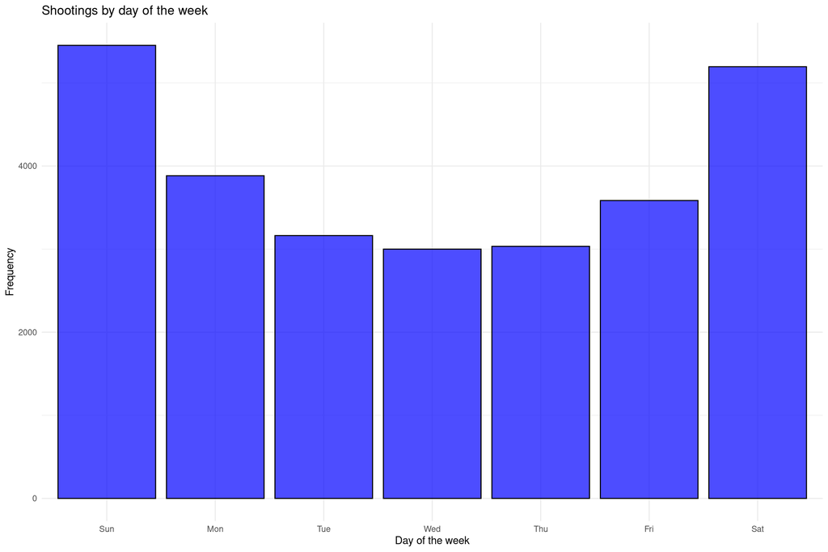

```r
df$weekday <- wday(as.Date(df$OCCUR_DATE, format = "%m/%d/%Y"), label = TRUE)

df$weekday <- factor(df$weekday, levels = c("Sun", "Mon", "Tue", "Wed", "Thu", "Fri", "Sat"))

ggplot(df, aes(x = weekday)) +
  geom_bar(fill = "blue", alpha = 0.7, color = "black") +
  labs(title = "Shootings by day of the week",
       x = "Day of the week",
       y = "Frequency") +
  theme_minimal()
```

This is interesting to see Wednesday is the safest and the weekends are riskiest. Here are the reasons I could think of

1. There may be increased activities for social gatherings and people go out more.
2. Increased alcohol consumption. People may drink more alcohol since it is holiday.

Or it may be because of other causes which I may not realize.

### 3. Distribution of races

Let us explore the races involved.

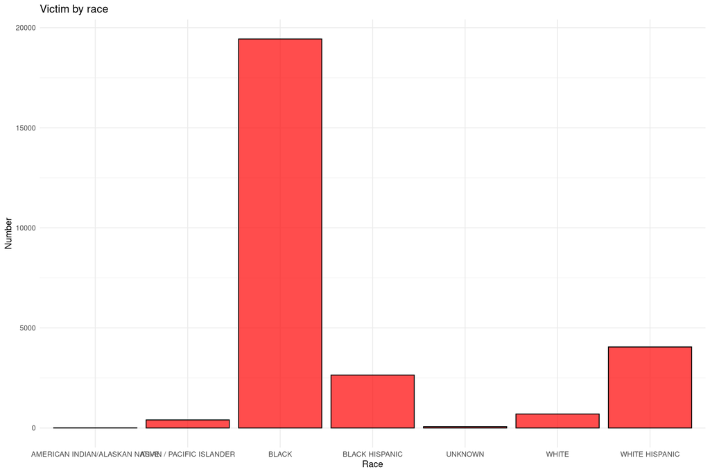

```r
ggplot(df, aes(x = VIC_RACE)) +
  geom_bar(fill = "red", alpha = 0.7, color = "black") +
  labs(title = "Victim by race",
       x = "Race",
       y = "Number") +
  theme_minimal()
```

The data may be biased here because of obvious disproportional distributions.

#### The numbers are too different so I will use LOG SCALE to compare victim and **perpetrator** distributions.

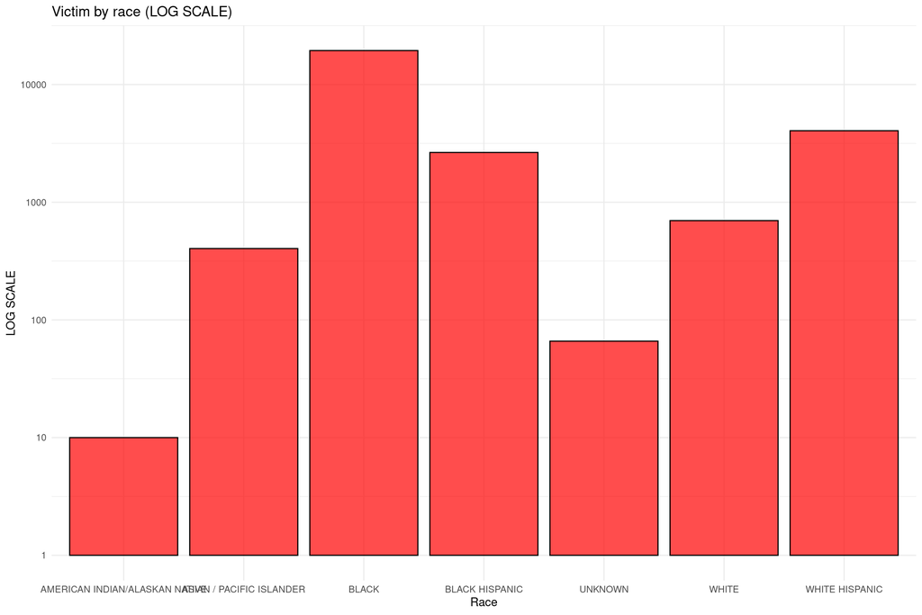

```r
ggplot(df, aes(x = VIC_RACE)) +
  geom_bar(fill = "red", alpha = 0.7, color = "black") +
  labs(title = "Victim by race (LOG SCALE)",
       x = "Race",
       y = "LOG SCALE") +
  scale_y_log10() +
  theme_minimal()
```

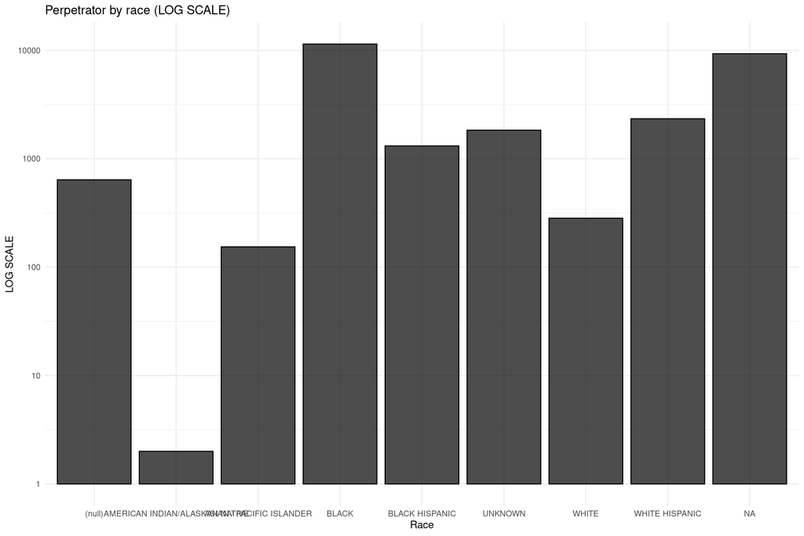

```r
ggplot(df, aes(x = PERP_RACE)) +
  geom_bar(fill = "black", alpha = 0.7, color = "black") +
  labs(title = "Perpetrator by race (LOG SCALE)",
       x = "Race",
       y = "LOG SCALE") +
  scale_y_log10() +
  theme_minimal()
```

### 4. Distributions of Victim Races by District

Let’s explore the distributions of races by districts are equal.

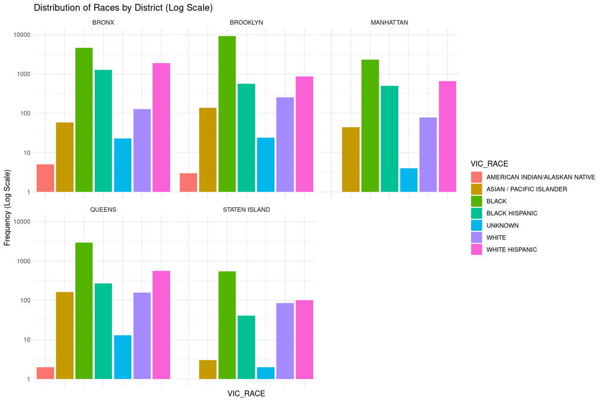

```r
library(ggplot2)

ggplot(df, aes(x = VIC_RACE)) +
  geom_histogram(stat = "count", aes(fill = VIC_RACE), position = "dodge") +
  facet_wrap(~ BORO) +
  scale_y_log10() +
  ylab("Frequency (Log Scale)") +
  ggtitle("Distribution of Races by District (Log Scale)") +
  theme_minimal() +
  theme(axis.text.x=element_blank())
```

We can see that all districts are more of less similarly distributed.

### 5. Distributions of Victim Age Group by District

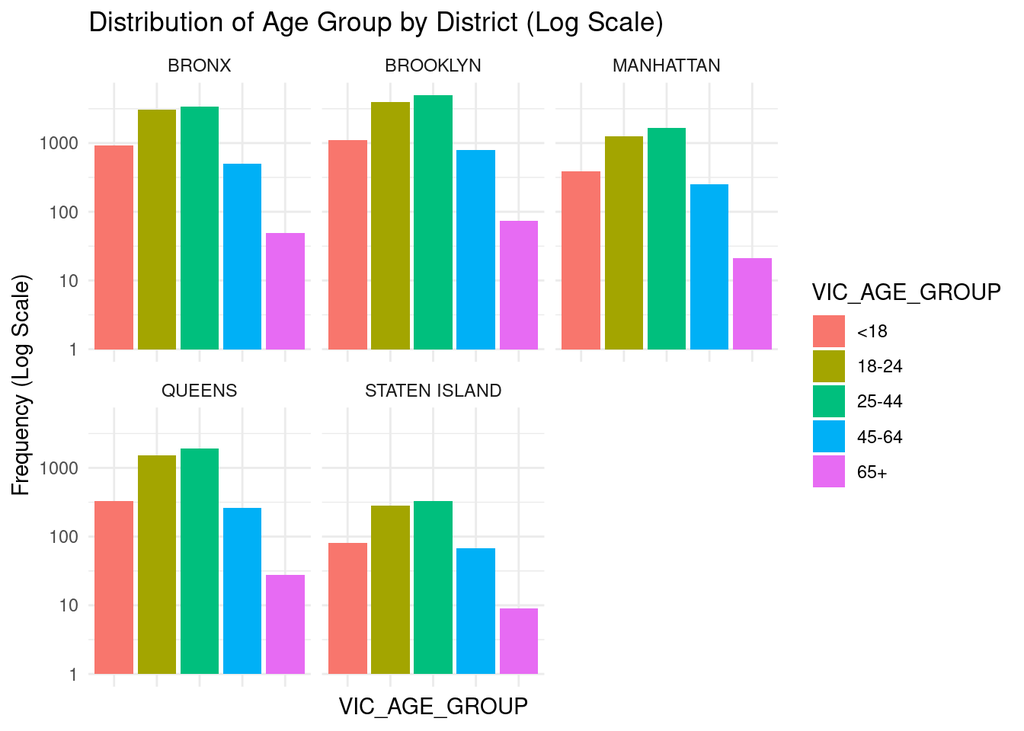

```r
df <- df[!(df$VIC_AGE_GROUP == "UNKNOWN" | df$VIC_AGE_GROUP == 1022),]
ggplot(df, aes(x = VIC_AGE_GROUP)) +
  geom_histogram(stat = "count", aes(fill = VIC_AGE_GROUP), position = "dodge") +
  facet_wrap(~ BORO) +
  scale_y_log10() +
  ylab("Frequency (Log Scale)") +
  ggtitle("Distribution of Age Group by District (Log Scale)") +
  theme_minimal() +
  theme(axis.text.x=element_blank())
```

They all seem to distribute similarly.

## Modelling

I am going to perform logistic regression statistical murder flag. I will handpick the features I want to explore. Here are the features I will use

OCCUR_TIME, PRECINT, PERP_AGE_GROUP, PERP_SEX, PERP_RACE, VIC_AGE_GROUP, VIC_SEX, VIC_RACE

### Data Cleaning

```r
model_df <- df[, c("OCCUR_TIME", "PRECINCT", "PERP_AGE_GROUP", "PERP_SEX", "PERP_RACE", "VIC_AGE_GROUP", "VIC_SEX", "VIC_RACE", "STATISTICAL_MURDER_FLAG")]

model_df <- na.omit(model_df)
model_df <- model_df[!apply(model_df == "UNKNOWN", 1, any), ]

model_df$TIME_OF_DAY <- factor(hour(hms(model_df$OCCUR_TIME)))
```

```r
model_df[] <- lapply(model_df, factor)
```

```r
table(model_df$STATISTICAL_MURDER_FLAG)
```

```
##
## FALSE  TRUE
## 11170  3424
```

But the data is imbalanced. Imbalanced datasets are not suitable to use for machine learning modelling. I will sample 3000 from flag TRUE and 3000 from flag FALSE

I will handpick the features I want to explore.

### Feature Selection

```r
sampled_df <- model_df %>%
  group_by(STATISTICAL_MURDER_FLAG) %>%
  sample_n(3000, replace = FALSE) %>%
  ungroup()
```

```r
set.seed(123)
sample <- sample(c(TRUE, FALSE), nrow(sampled_df), replace=TRUE, prob=c(0.8,0.2))
train  <- sampled_df[sample, ]
test   <- sampled_df[!sample, ]
```

```r
model = glm(STATISTICAL_MURDER_FLAG ~ PRECINCT + PERP_AGE_GROUP + PERP_SEX + PERP_RACE + VIC_AGE_GROUP + VIC_SEX + VIC_RACE + TIME_OF_DAY, data = train, family = binomial)
```

```r
predictions = predict(model, newdata = test, type = "response")
```

```r
predicted_labels = ifelse(predictions > 0.5, TRUE, FALSE)

library(caret)
confusionMatrix(as.factor(predicted_labels), as.factor(test$STATISTICAL_MURDER_FLAG))
```

```
## Confusion Matrix and Statistics
##
##           Reference
## Prediction FALSE TRUE
##      FALSE   348  305
##      TRUE    244  299
##
##                Accuracy : 0.541
##                  95% CI : (0.5122, 0.5695)
##     No Information Rate : 0.505
##     P-Value [Acc > NIR] : 0.00696
##
##                   Kappa : 0.0828
##
##  Mcnemar's Test P-Value : 0.01045
##
##             Sensitivity : 0.5878
##             Specificity : 0.4950
##          Pos Pred Value : 0.5329
##          Neg Pred Value : 0.5506
##              Prevalence : 0.4950
##          Detection Rate : 0.2910
##    Detection Prevalence : 0.5460
##       Balanced Accuracy : 0.5414
##
##        'Positive' Class : FALSE
##
```

### Conclusion

So, the model accuracy is not optimal. One of the possible reasons could be that the NYPD determine statistical murder flag by some kinds of private data or they use crime scene information which I do not have access. In the future, I will research more about how data scientists are looking at this kind of data and perform which kinds of modelling and data visualization.